# Submission_Lab4

### Lab-4 Report

By: Aniket Tiwari  
ID: 8866818

```python
from sklearn import datasets
from sklearn.model_selection import train_test_split
from sklearn.linear_model import LinearRegression
import pandas as pd
from sklearn.preprocessing import PolynomialFeatures
from sklearn.metrics import r2_score, mean_absolute_error
import numpy as np
import matplotlib.pyplot as plt
import warnings
warnings.filterwarnings('ignore')
```

### Problem:

The principal objective of this research is to create a predictive model that can precisely calculate an individual's risk of developing diabetes based only on their body mass index (BMI). The purpose of this approach is to provide healthcare practitioners with a useful screening tool so they may identify high-risk individuals and prioritise interventions.

```python
diabetes_x, diabetes_y = datasets.load_diabetes(as_frame=True, scaled=False, return_X_y=True)
diabetes_x.head()
```

|  | age | sex | bmi | bp | s1 | s2 | s3 | s4 | s5 | s6 |
| --- | --- | --- | --- | --- | --- | --- | --- | --- | --- | --- |
| 0 | 59.0 | 2.0 | 32.1 | 101.0 | 157.0 | 93.2 | 38.0 | 4.0 | 4.8598 | 87.0 |
| 1 | 48.0 | 1.0 | 21.6 | 87.0 | 183.0 | 103.2 | 70.0 | 3.0 | 3.8918 | 69.0 |
| 2 | 72.0 | 2.0 | 30.5 | 93.0 | 156.0 | 93.6 | 41.0 | 4.0 | 4.6728 | 85.0 |
| 3 | 24.0 | 1.0 | 25.3 | 84.0 | 198.0 | 131.4 | 40.0 | 5.0 | 4.8903 | 89.0 |
| 4 | 50.0 | 1.0 | 23.0 | 101.0 | 192.0 | 125.4 | 52.0 | 4.0 | 4.2905 | 80.0 |

```python
bmi = diabetes_x['bmi']

print("\nSummary statistics for BMI:")
bmi.describe()
```

```
Summary statistics for BMI:
```

```
count    442.000000
mean      26.375792
std        4.418122
min       18.000000
25%       23.200000
50%       25.700000
75%       29.275000
max       42.200000
Name: bmi, dtype: float64
```

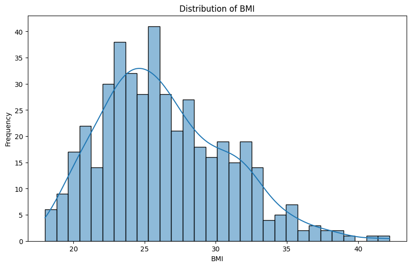

```python
import seaborn as sns

plt.figure(figsize=(10, 6))
sns.histplot(bmi, kde=True, bins=30)
plt.title('Distribution of BMI')
plt.xlabel('BMI')
plt.ylabel('Frequency')
plt.show()
```

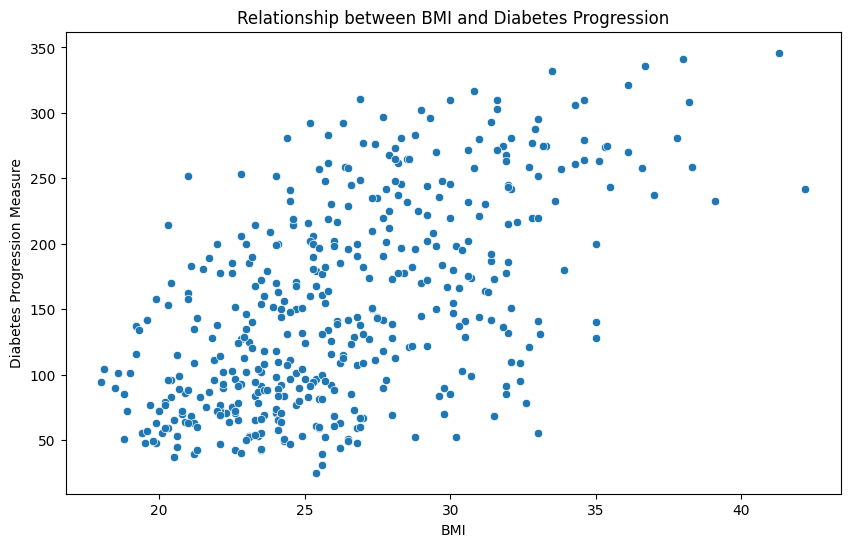

```python
# Visualization of the relationship between BMI and diabetes progression
plt.figure(figsize=(10, 6))
sns.scatterplot(x=bmi, y=diabetes_y)
plt.title('Relationship between BMI and Diabetes Progression')
plt.xlabel('BMI')
plt.ylabel('Diabetes Progression Measure')
plt.show()
```

A scatter plot showing the correlation between BMI and the diabetes progression metric is shown. The plot demonstrates a positive correlation between the advancement of diabetes and BMI, indicating that higher BMI values are typically linked to a faster rate of diabetes progression. The large range of points, however, indicates significant variability, and BMI may not be the only indicator of how quickly diabetes may advance.

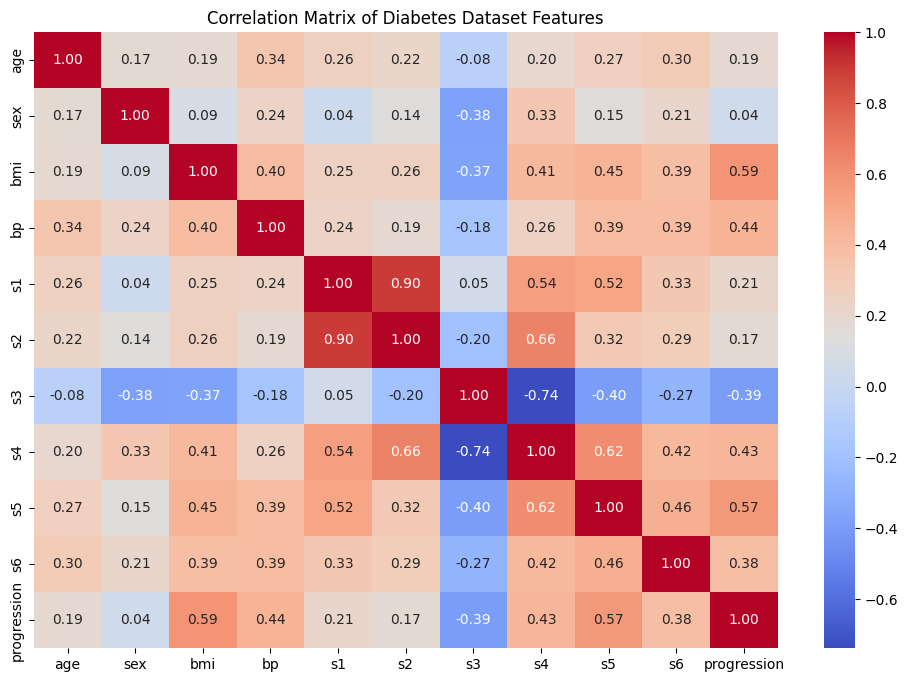

```python
correlation_matrix = pd.concat([diabetes_x, diabetes_y.rename('progression')], axis=1).corr()
plt.figure(figsize=(12, 8))
sns.heatmap(correlation_matrix, annot=True, cmap='coolwarm', fmt=".2f")
plt.title('Correlation Matrix of Diabetes Dataset Features')
plt.show()
```

The correlation matrix of the features in the dataset, such as age, sex, blood pressure (bp), BMI, six blood serum measurements (s1 through s6), and the diabetes development measure, is shown in the heatmap. The salient observations are:

- The scatter plot's pattern is supported by the moderately positive association (about 0.59) between BMI and the course of diabetes.
- Significant correlations have also been found between several of the serum measurements (such as s1 and s2), suggesting that the dataset may be multicollinear.
- In addition to BMI, blood pressure (bp) and other serum parameters also exhibit some degree of connection with the onset of diabetes, indicating that they could be valuable predictors.
- In this dataset, age has a relatively weak association with the advancement of diabetes, indicating that it may not be as reliable a predictor as some of the other characteristics.

```python
# Check for missing values
print("Missing values before handling:")
print(diabetes_x.isnull().sum())
```

```
Missing values before handling:
age    0
sex    0
bmi    0
bp     0
s1     0
s2     0
s3     0
s4     0
s5     0
s6     0
dtype: int64
```

```python
# Removing duplicates if any
diabetes_x.drop_duplicates(inplace=True)

# Check for outliers in BMI using the IQR method
Q1 = diabetes_x['bmi'].quantile(0.25)
Q3 = diabetes_x['bmi'].quantile(0.75)
IQR = Q3 - Q1
lower_bound = Q1 - 1.5 * IQR
upper_bound = Q3 + 1.5 * IQR

# Identifying outliers
outliers = diabetes_x[(diabetes_x['bmi'] < lower_bound) | (diabetes_x['bmi'] > upper_bound)]
print(f"\nNumber of outliers in BMI before removal: {len(outliers)}")
```

```
Number of outliers in BMI before removal: 3
```

Only three outliers present in the dataset. No need to remove the outliers

```python
diabetes_x.describe()
```

|  | age | sex | bmi | bp | s1 | s2 | s3 | s4 | s5 | s6 |
| --- | --- | --- | --- | --- | --- | --- | --- | --- | --- | --- |
| count | 442.000000 | 442.000000 | 442.000000 | 442.000000 | 442.000000 | 442.000000 | 442.000000 | 442.000000 | 442.000000 | 442.000000 |
| mean | 48.518100 | 1.468326 | 26.375792 | 94.647014 | 189.140271 | 115.439140 | 49.788462 | 4.070249 | 4.641411 | 91.260181 |
| std | 13.109028 | 0.499561 | 4.418122 | 13.831283 | 34.608052 | 30.413081 | 12.934202 | 1.290450 | 0.522391 | 11.496335 |
| min | 19.000000 | 1.000000 | 18.000000 | 62.000000 | 97.000000 | 41.600000 | 22.000000 | 2.000000 | 3.258100 | 58.000000 |
| 25% | 38.250000 | 1.000000 | 23.200000 | 84.000000 | 164.250000 | 96.050000 | 40.250000 | 3.000000 | 4.276700 | 83.250000 |
| 50% | 50.000000 | 1.000000 | 25.700000 | 93.000000 | 186.000000 | 113.000000 | 48.000000 | 4.000000 | 4.620050 | 91.000000 |
| 75% | 59.000000 | 2.000000 | 29.275000 | 105.000000 | 209.750000 | 134.500000 | 57.750000 | 5.000000 | 4.997200 | 98.000000 |
| max | 79.000000 | 2.000000 | 42.200000 | 133.000000 | 301.000000 | 242.400000 | 99.000000 | 9.090000 | 6.107000 | 124.000000 |

Splitting the dataset into training, testing and validation sets

```python
# First, split into train (70%) and temp (30%) sets
X_train, X_temp, y_train, y_temp = train_test_split(diabetes_x, diabetes_y, test_size=0.3, random_state=42)

# Then, split the temp set equally into validation and test sets (15% each of the total data)
X_val, X_test, y_val, y_test = train_test_split(X_temp, y_temp, test_size=0.5, random_state=42)
```

```python
# Defining a method for calculating MAPE
def MAPE(y_true, y_pred):
    return np.mean(np.abs((y_true - y_pred) / y_true)) * 100
```

Applying the polynomial regression on the BMI feature

```python
from sklearn.linear_model import LinearRegression
from sklearn.preprocessing import PolynomialFeatures
from sklearn.pipeline import make_pipeline
polynomial_models = {}

for degree in range(6):
    model = make_pipeline(PolynomialFeatures(degree), LinearRegression())
    model.fit(X_train[['bmi']], y_train)
    polynomial_models[f"degree_{degree}"] = model
```

Calculating the metrics for each degree

```python
from sklearn.metrics import r2_score, mean_absolute_error, mean_absolute_percentage_error

# Initialize dictionaries to store the metrics for training and validation
train_metrics = {'R_squared': [], 'MAE': [], 'MAPE': []}
val_metrics = {'R_squared': [], 'MAE': [], 'MAPE': []}

for degree in range(6):
    # Retrieve the model for the current degree
    model = polynomial_models[f"degree_{degree}"]

    # Predict on the training data and calculate metrics
    y_train_pred = model.predict(X_train[['bmi']])
    train_r2 = r2_score(y_train, y_train_pred)
    train_mae = mean_absolute_error(y_train, y_train_pred)
    train_mape = mean_absolute_percentage_error(y_train, y_train_pred)

    # Store the metrics
    train_metrics['R_squared'].append(train_r2)
    train_metrics['MAE'].append(train_mae)
    train_metrics['MAPE'].append(train_mape)

    # Predict on the validation data and calculate metrics
    y_val_pred = model.predict(X_val[['bmi']])
    val_r2 = r2_score(y_val, y_val_pred)
    val_mae = mean_absolute_error(y_val, y_val_pred)
    val_mape = mean_absolute_percentage_error(y_val, y_val_pred)

    # Store the metrics
    val_metrics['R_squared'].append(val_r2)
    val_metrics['MAE'].append(val_mae)
    val_metrics['MAPE'].append(val_mape)
```

```python
for degree in range(6):
    print(f"Degree {degree} Model Metrics:")
    print(f"Training Data: R-squared: {train_metrics['R_squared'][degree]:.2f}, "
          f"MAE: {train_metrics['MAE'][degree]:.2f}, "
          f"MAPE: {train_metrics['MAPE'][degree]:.2f}%")
    print(f"Validation Data: R-squared: {val_metrics['R_squared'][degree]:.2f}, "
          f"MAE: {val_metrics['MAE'][degree]:.2f}, "
          f"MAPE: {val_metrics['MAPE'][degree]:.2f}%\n")
```

```
Degree 0 Model Metrics:
Training Data: R-squared: 0.00, MAE: 66.71, MAPE: 0.64%
Validation Data: R-squared: -0.01, MAE: 62.04, MAPE: 0.58%

Degree 1 Model Metrics:
Training Data: R-squared: 0.37, MAE: 51.95, MAPE: 0.48%
Validation Data: R-squared: 0.30, MAE: 48.27, MAPE: 0.42%

Degree 2 Model Metrics:
Training Data: R-squared: 0.37, MAE: 51.88, MAPE: 0.48%
Validation Data: R-squared: 0.30, MAE: 48.27, MAPE: 0.42%

Degree 3 Model Metrics:
Training Data: R-squared: 0.37, MAE: 51.88, MAPE: 0.48%
Validation Data: R-squared: 0.30, MAE: 48.24, MAPE: 0.42%

Degree 4 Model Metrics:
Training Data: R-squared: 0.37, MAE: 51.77, MAPE: 0.48%
Validation Data: R-squared: 0.26, MAE: 48.37, MAPE: 0.41%

Degree 5 Model Metrics:
Training Data: R-squared: 0.37, MAE: 51.76, MAPE: 0.48%
Validation Data: R-squared: 0.30, MAE: 47.35, MAPE: 0.41%
```

- The worst performing model is the Degree 0 model, which is just a horizontal line with an R-squared of 0 on the training data and -0.01 on the validation data. This shows that there is no correlation between the expected and actual results, which is to be expected from a model that remains constant when BMI varies.
- All measures show a significant improvement when we approach to Degree 1, which is a simple linear model. The R-squared values increase to 0.37 for training and 0.30 for validation, indicating that the model for the training and validation sets accounts for roughly 37% and 30% of the variability in the illness development, respectively. Improved predictive accuracy is indicated by the significant decreases in the MAE and MAPE.
- The R-squared value for the training data does not change much from Degree 2 to Degree 5; it stays at roughly 0.37. The R-squared varies significantly but doesn't consistently improve for the validation data. Compared to the simpler models, Degree 4 actually exhibits a lower R-squared value, which could indicate overfitting to the training set.
- The models' MAE and MAPE metrics exhibit negligible variations as well; Degree 5's MAE and MAPE on the validation set are marginally lower than those of the other models. Nevertheless, the enhancements are slight and might not warrant the heightened intricacy of the model.
- In light of these findings, the Degree 1 model is clearly the best option. Its consistent metrics across the training and validation datasets demonstrate that it exhibits significant predictive power without overfitting, offering a fair balance between complexity and performance.

```python
from sklearn.metrics import r2_score, mean_squared_error, mean_absolute_error

# Assuming model for Degree 1 is stored in polynomial_models['degree_1']
degree_1_model = polynomial_models['degree_1']

# Predict on the test set
y_test_pred = degree_1_model.predict(X_test[['bmi']])

# Calculate metrics
test_r2 = r2_score(y_test, y_test_pred)
test_mse = mean_squared_error(y_test, y_test_pred)
test_mae = mean_absolute_error(y_test, y_test_pred)

print(f"Test Set Metrics for Degree 1 Model:")
print(f"R-Squared: {test_r2:.2f}")
print(f"MSE: {test_mse:.2f}")
print(f"MAE: {test_mae:.2f}")
```

```
Test Set Metrics for Degree 1 Model:
R-Squared: 0.26
MSE: 4198.45
MAE: 52.88
```

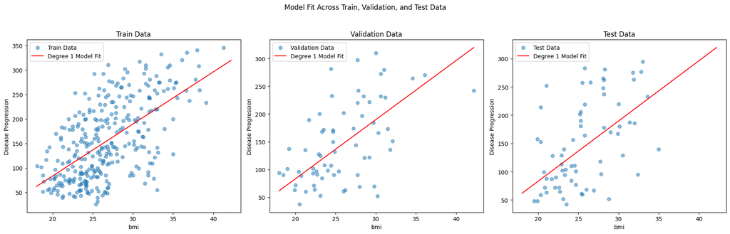

```python
import matplotlib.pyplot as plt
import numpy as np

bmi_range = np.linspace(min(X_train['bmi'].min(), X_val['bmi'].min(), X_test['bmi'].min()),
                        max(X_train['bmi'].max(), X_val['bmi'].max(), X_test['bmi'].max()), 100).reshape(-1, 1)

predicted_progression = degree_1_model.predict(bmi_range)

# Plotting subplots for train, validation, and test sets
fig, axes = plt.subplots(nrows=1, ncols=3, figsize=(18, 6))
fig.suptitle('Model Fit Across Train, Validation, and Test Data')

# Train Data Plot
axes[0].scatter(X_train['bmi'], y_train, label='Train Data', alpha=0.5)
axes[0].plot(bmi_range, predicted_progression, color='red', label='Degree 1 Model Fit')
axes[0].set_xlabel('bmi')
axes[0].set_ylabel('Disease Progression')
axes[0].set_title('Train Data')
axes[0].legend()

# Validation Data Plot
axes[1].scatter(X_val['bmi'], y_val, label='Validation Data', alpha=0.5)
axes[1].plot(bmi_range, predicted_progression, color='red', label='Degree 1 Model Fit')
axes[1].set_xlabel('bmi')
axes[1].set_ylabel('Disease Progression')
axes[1].set_title('Validation Data')
axes[1].legend()

# Test Data Plot
axes[2].scatter(X_test['bmi'], y_test, label='Test Data', alpha=0.5)
axes[2].plot(bmi_range, predicted_progression, color='red', label='Degree 1 Model Fit')
axes[2].set_xlabel('bmi')
axes[2].set_ylabel('Disease Progression')
axes[2].set_title('Test Data')
axes[2].legend()

plt.tight_layout(rect=[0, 0.03, 1, 0.95])
plt.show()
```

```python
beta_0 = degree_1_model.named_steps['linearregression'].intercept_
beta_1 = degree_1_model.named_steps['linearregression'].coef_[1]
bmi_value = 30

expected_progression = beta_0 + (beta_1 * bmi_value)

model_prediction = degree_1_model.predict(np.array([[bmi_value]]))

print(f"Manual calculation of expected disease progression: {expected_progression:.2f}")
print(f"Model prediction for bmi value {bmi_value}: {model_prediction[0]:.2f}")
```

```
Manual calculation of expected disease progression: 189.65
Model prediction for bmi value 30: 189.65
```

```python
from sklearn.preprocessing import PolynomialFeatures

for degree in range(6):
    poly_features = PolynomialFeatures(degree)
    poly_features.fit(X_train[['bmi']])
    feature_names = poly_features.get_feature_names_out()
    num_parameters = len(feature_names) + 1
    print(f"Degree {degree} model has {num_parameters} trainable parameters")
```

```
Degree 0 model has 2 trainable parameters
Degree 1 model has 3 trainable parameters
Degree 2 model has 4 trainable parameters
Degree 3 model has 5 trainable parameters
Degree 4 model has 6 trainable parameters
Degree 5 model has 7 trainable parameters
```